# CoViDataIT: CoViD Open Data in Italian Regions

Leonardo Cefalo

2025-09-01

## Data source

This dataset relies on the data gathered by Italian regions, validated by the Ministry of Health and eventually shared by the Civil Protection Department. Final open data are available [at this GitHub repository](https://github.com/pcm-dpc/COVID-19).

This dataset is not meant to add any element to the precious information already published by the Civil Protection Department, it is just an `R`-based tool to download automatically the regional level data

## Usage example

At the time being, the usage of the retrieval function `Get_CoViData` is quite simple. The user chooses the time interval across which data are to be downloaded.

Please notice that no data are available prior to Febryary 24th 2020 neither after January 10th 2025.

If, for instance, the user is interested to get data from January 1st to January 31st 2022, the function call is the following; verbose output is suppressed.

```r
dd <- Get_CoViData(date_from = "2022-01-01", date_to = "2022-01-31", verbose = F)
```

Notes are quite obnoxious, so here we remove them

```r
dd <- dd[, -grep("Notes", names(dd))]
```

|  | Date | State | Region_code | Region_name | Latitude | Longitude | Hospitalised_with_symptoms | Critical_care | Tot_hospitalised | Home_isolation | Tot_positives | Positives_variation | New_cases | Discharged | Deaths | Diagnostic_suspect_tested | Screening_tested | Tot_cases | Tot_tests | Tested_cases | Intensive_care_new | Tot_cases_molecular_tests | Tot_cases_quick_test | Molecular_tests | Quick_tests | NUTS1_code | NUTS2_code | New_tests | positive_rate |
| --- | --- | --- | --- | --- | --- | --- | --- | --- | --- | --- | --- | --- | --- | --- | --- | --- | --- | --- | --- | --- | --- | --- | --- | --- | --- | --- | --- | --- | --- |
| 22 | 2022-01-02 | ITA | 13 | Abruzzo | 42.35122196 | 13.39843823 | 184 | 22 | 206 | 21794 | 22000 | 1127 | 1135 | 87087 | 2642 |  |  | 111729 | 3591519 | 1029737 | 2 | 104649 | 7080 | 1740705 | 1850814 | ITF | ITF1 | 7919 | 0.1433261775476702 |
| 23 | 2022-01-02 | ITA | 17 | Basilicata | 40.63947052 | 15.80514834 | 71 | 2 | 73 | 5554 | 5627 | 255 | 322 | 31197 | 635 |  |  | 37459 | 550894 | 265197 | 1 | 37459 | 0 | 522731 | 28163 | ITF | ITF5 | 2125 | 0.1515294117647059 |
| 24 | 2022-01-02 | ITA | 18 | Calabria | 38.90597598 | 16.59440194 | 312 | 28 | 340 | 17297 | 17637 | 611 | 793 | 94502 | 1630 |  |  | 113769 | 1682142 | 1358127 | 2 | 111389 | 2380 | 1272050 | 410092 | ITF | ITF6 | 3754 | 0.2112413425679275 |
| 25 | 2022-01-02 | ITA | 15 | Campania | 40.83956555 | 14.25084984 | 718 | 55 | 773 | 93605 | 94378 | 3989 | 5192 | 499490 | 8474 |  |  | 602342 | 9629418 | 3920867 | 7 | 590754 | 11588 | 6555622 | 3073796 | ITF | ITF3 | 29677 | 0.1749502982107356 |
| 26 | 2022-01-02 | ITA | 8 | Emilia-Romagna | 44.49436681 | 11.3417208 | 1451 | 130 | 1581 | 95471 | 97052 | 8186 | 9090 | 446972 | 14239 |  |  | 558263 | 11738029 | 2407107 | 10 | 547665 | 10598 | 7329428 | 4408601 | ITH | ITH5 | 17490 | 0.5197255574614065 |
| 27 | 2022-01-02 | ITA | 6 | Friuli Venezia Giulia | 45.6494354 | 13.76813649 | 298 | 28 | 326 | 14440 | 14766 | 918 | 1188 | 140611 | 4228 |  |  | 159605 | 4556503 | 969305 | 4 | 138151 | 21454 | 2661326 | 1895177 | ITH | ITH4 | 5339 | 0.2225135793219704 |
| 28 | 2022-01-02 | ITA | 12 | Lazio | 41.89277044 | 12.48366722 | 1173 | 152 | 1325 | 89076 | 90401 | 6920 | 7993 | 425921 | 9290 |  |  | 525612 | 13065385 | 5078283 | 8 | 507161 | 18451 | 6952288 | 6113097 | ITI | ITI4 | 36248 | 0.2205087177223571 |
| 29 | 2022-01-02 | ITA | 7 | Liguria | 44.41149315 | 8.9326992 | 510 | 47 | 557 | 13302 | 13859 | 427 | 1265 | 134307 | 4591 |  |  | 152757 | 3573911 | 1052169 | 3 | 152757 | 0 | 2006357 | 1567554 | ITC | ITC3 | 6229 | 0.2030823567185744 |
| 30 | 2022-01-02 | ITA | 3 | Lombardia | 45.46679409 | 9.190347404 | 2052 | 216 | 2268 | 289825 | 292093 | 7196 | 10425 | 937826 | 35140 |  |  | 1265059 | 25183247 | 6868839 | 15 | 993570 | 271489 | 13094013 | 12089234 | ITC | ITC4 | 44172 | 0.2360092366204836 |
| 31 | 2022-01-02 | ITA | 11 | Marche | 43.61675973 | 13.5188753 | 227 | 50 | 277 | 7832 | 8109 | 348 | 699 | 136421 | 3252 |  |  | 147782 | 2030264 | 1194317 | 4 | 147782 | 0 | 1654957 | 375307 | ITI | ITI3 | 3459 | 0.202081526452732 |

[output cut: 620 more lines]

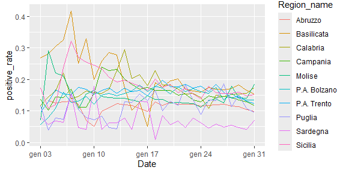

```r
dd_south <- dd[which(dd$Region_code > 12),]
ggplot2::ggplot(dd_south[-c(1:21), ]) +
  ggplot2::aes(x = .data$Date, y = .data$positive_rate) +
  ggplot2::geom_line(ggplot2::aes(color = .data$Region_name))
```

## Unorthodox application: a spatial analysis over yearly totals

Here we propose another usage example, which however wastes much of the available information. Specifically, we provide a spatial model for the yearly total infections for the years allowing for full data record, i.e. 2021-2024. This simply requires the data at the end of each year. For 2020/12/31, for instance, we do as follows. Specifically, we filter out the infections recorded in different provinces and the ones for which the province is not available. Please notice this did not happen for regions. I guess it is because the health infrastructure is managed on the regional basis, so discrepancies in between-province data records are resolved when aggregating for provinces. I get this may sound nonsense, as sai it is just a very rough guess.

```r
cases.EoY20 <- Get_CoViData(date_from = "2020-12-31", date_to = "2020-12-31",
                            level = "NUTS-3") %>%
  dplyr::filter(nchar(.data$Province_abbreviation)>0) %>%
  dplyr::rename(Tot_cases_EoY20 = .data$Tot_cases) %>%
  dplyr::select(-c("Latitude", "Longitude", "Notes"))
```

```
#> Data downloaded for 2020-12-31
#> 0.08 seconds needed to retrieve CoViD data from 2020-12-31 to 2020-12-31
```

We do the same for 2021-24 (not shown)

```
#> Data downloaded for 2021-12-31
#> 1.19 seconds needed to retrieve CoViD data from 2021-12-31 to 2021-12-31
#> Data downloaded for 2022-12-31
#> 0.29 seconds needed to retrieve CoViD data from 2022-12-31 to 2022-12-31
#> Data downloaded for 2023-12-31
#> 0.07 seconds needed to retrieve CoViD data from 2023-12-31 to 2023-12-31
#> Data downloaded for 2024-12-31
#> 0.28 seconds needed to retrieve CoViD data from 2024-12-31 to 2024-12-31
```

Then we add the population at January 1st, retrieved from the ISTAT website, and a shapefile for province boundaries. Luckily, no change of boundaries seems to have happened between 2021/01/01 and 2024/12/31. The shapefile is scraped with the [SchoolDataIT package](https://CRAN.R-project.org/package=SchoolDataIT).

```r
if(!rlang::is_installed("SchoolDataIT")) {
  install.packages("SchoolDataIT")
}
Prov21_shp <- SchoolDataIT::Get_Shapefile(2021, level ="NUTS-3")
```

We show the spatial pattern of 2021 data

[interactive chart not shown]